# Project Name Here

#### Top 250 Most Differentially Expressed Genes in Pairwise Group Comparisons

View data for the 250 most statistically relevant genes that were differentially expressed in the following groups: * G0 is control CD34 * G1 is Chronic Phase * G2 is Accelerated Phase * G3 is Blast Crisis

This first round, I only did 5 pairwise contrasts for the following: G1 and G0 (chronic and control) G2 and G0 (accelerated and control) G3 and G0 (crisis and control) G3 and G2 (crisis vs accelerated. not expected to be largely different) G3 and G1 (chronic and blast crisis, least and most advanced disease states)

```r
#by default, top table saves a dataframe with all columns of the gene feature data in the expression dataset.
#subset top table here down to only the columns we care about:
subset(tT, select=c("P.Value","Gene.symbol"
                    ,"G1...G0","G2...G0","G3...G0","G3...G2","G3...G1"
                    ,"AveExpr"))
```

|  | P.Value | Gene.symbol | G1...G0 | G2...G0 | G3...G0 | G3...G2 | G3...G1 | AveExpr |
| --- | --- | --- | --- | --- | --- | --- | --- | --- |
| 10012672278 | 4.326511e-32 | GAK | 0.4329386 | 0.233988095 | 0.0801541667 | -0.153833929 | -0.3527844 | -0.17654615 |
| 10012667916 | 6.967740e-29 | VDAC2 | -0.5550561 | -0.257616667 | -0.0349091667 | 0.222707500 | 0.5201470 | 0.27289402 |
| 10012685105 | 1.477568e-28 | FLJ40142 | -0.7656912 | -0.257484615 | -0.0768650000 | 0.180619615 | 0.6888262 | 0.49049397 |
| 10012688029 | 2.934467e-28 | ITGAM | 1.6470175 | 1.517516667 | 0.6140241667 | -0.903492500 | -1.0329934 | -0.60546752 |
| 10012684680 | 4.354013e-28 | ITGB2 | 1.1088035 | 0.903050000 | 0.3960923077 | -0.506957692 | -0.7127112 | -0.41529914 |
| 10012674495 | 9.584159e-28 | BCAT1 | -0.9783939 | -0.685314286 | -0.1152825000 | 0.570031786 | 0.8631114 | 0.38858034 |
| 10012685898 | 1.084776e-27 | TCP1 | -0.6470132 | -0.473578571 | -0.2423875000 | 0.231191071 | 0.4046257 | 0.23700342 |
| 10012676178 | 1.636838e-27 | CD109 | -1.2332658 | -0.468750000 | -0.1486200000 | 0.320130000 | 1.0846458 | 0.58332821 |
| 10012672593 | 3.100368e-27 | SOCS2 | -0.5935421 | -0.009833333 | 0.4249766667 | 0.434810000 | 1.0185188 | 0.54008632 |
| 10012672247 | 3.773066e-27 | FGR | 1.2933648 | 1.091309524 | 0.4451431373 | -0.646166387 | -0.8482216 | -0.45909252 |

[output cut: 240 more lines]

```r
tT
```

|  | ID | Gene.title | Gene.symbol | Gene.ID | UniGene.title | UniGene.symbol | UniGene.ID | Nucleotide.Title | GI | GenBank.Accession | Platform_CLONEID | Platform_ORF | Platform_SPOTID | Chromosome.location | Chromosome.annotation | GO.Function | GO.Process | GO.Component | GO.Function.ID | GO.Process.ID | GO.Component.ID | G1...G0 | G2...G0 | G3...G0 | G3...G2 | G3...G1 | AveExpr | F | P.Value | … |
| --- | --- | --- | --- | --- | --- | --- | --- | --- | --- | --- | --- | --- | --- | --- | --- | --- | --- | --- | --- | --- | --- | --- | --- | --- | --- | --- | --- | --- | --- | --- |
| 10012672278 | 10012672278 | cyclin G associated kinase | GAK | 2580 |  |  |  | Homo sapiens cyclin G associated kinase (GAK), mRNA | 157384970 | NM_005255 | NA | NA |  | 4p16 | Chromosome 4, NC_000004.10 (833065..916174, complement) | ATP binding///heat shock protein binding///kinase activity///nucleotide binding///protein kinase activity///protein serine/threonine kinase activity///transferase activity | cell cycle///protein amino acid phosphorylation | Golgi apparatus///cell junction///cytoplasm | GO:0005524///GO:0031072///GO:0016301///GO:0000166///GO:0004672///GO:0004674///GO:0016740 | GO:0007049///GO:0006468 | GO:0005794///GO:0030054///GO:0005737 | 0.4329386 | 0.233988095 | 0.0801541667 | -0.153833929 | -0.3527844 | -0.17654615 | 100.76045 | 4.326511e-32 | … |
| 10012667916 | 10012667916 | voltage-dependent anion channel 2 | VDAC2 | 7417 |  |  |  | Homo sapiens voltage-dependent anion channel 2 (VDAC2), mRNA | 42476280 | NM_003375 | NA | NA |  | 10q22 | Chromosome 10, NC_000010.9 (76640569..76661212) | protein binding///voltage-gated anion channel activity///voltage-gated anion channel activity | anion transport///anion transport///transport | integral to membrane///membrane///mitochondrial outer membrane///mitochondrial outer membrane///mitochondrion///outer membrane | GO:0005515///GO:0008308///GO:0008308 | GO:0006820///GO:0006820///GO:0006810 | GO:0016021///GO:0016020///GO:0005741///GO:0005741///GO:0005739///GO:0019867 | -0.5550561 | -0.257616667 | -0.0349091667 | 0.222707500 | 0.5201470 | 0.27289402 | 83.97785 | 6.967740e-29 | … |
| 10012685105 | 10012685105 | FLJ40142 protein | FLJ40142 | 400073 |  |  |  | Homo sapiens FLJ40142 protein (FLJ40142), mRNA | 46409493 | NM_207435 | NA | NA |  | 12q24.11 | Chromosome 12, NC_000012.10 (108963366..108989883, complement) |  |  |  |  |  |  | -0.7656912 | -0.257484615 | -0.0768650000 | 0.180619615 | 0.6888262 | 0.49049397 | 82.87354 | 1.477568e-28 | … |
| 10012688029 | 10012688029 | integrin, alpha M (complement component 3 receptor 3 subunit) | ITGAM | 3684 |  |  |  | Homo sapiens integrin, alpha M (complement component 3 receptor 3 subunit) (ITGAM), mRNA | 88501733 | NM_000632 | NA | NA |  | 16p11.2 | Chromosome 16, NC_000016.8 (31178789..31251714) | calcium ion binding///glycoprotein binding///magnesium ion binding///protein binding///protein heterodimerization activity///receptor activity | cell adhesion///cell adhesion///integrin-mediated signaling pathway | integral to membrane///integrin complex///integrin complex///membrane | GO:0005509///GO:0001948///GO:0000287///GO:0005515///GO:0046982///GO:0004872 | GO:0007155///GO:0007155///GO:0007229 | GO:0016021///GO:0008305///GO:0008305///GO:0016020 | 1.6470175 | 1.517516667 | 0.6140241667 | -0.903492500 | -1.0329934 | -0.60546752 | 80.95221 | 2.934467e-28 | … |
| 10012684680 | 10012684680 | integrin, beta 2 (complement component 3 receptor 3 and 4 subunit) | ITGB2 | 3689 |  |  |  | Homo sapiens integrin, beta 2 (complement component 3 receptor 3 and 4 subunit) (ITGB2), transcript variant 1, mRNA | 188595673 | NM_000211 | NA | NA |  | 21q22.3 | Chromosome 21, NC_000021.7 (45130296..45165303, complement) | binding///protein binding///protein kinase binding///receptor activity | apoptosis///cell adhesion///cell adhesion///cell-cell signaling///cell-matrix adhesion///inflammatory response///integrin-mediated signaling pathway///integrin-mediated signaling pathway///leukocyte a… | integral to membrane///integrin complex///integrin complex///membrane///plasma membrane | GO:0005488///GO:0005515///GO:0019901///GO:0004872 | GO:0006915///GO:0007155///GO:0007155///GO:0007267///GO:0007160///GO:0006954///GO:0007229///GO:0007229///GO:0007159///GO:0030593///GO:0008360///GO:0050730 | GO:0016021///GO:0008305///GO:0008305///GO:0016020///GO:0005886 | 1.1088035 | 0.903050000 | 0.3960923077 | -0.506957692 | -0.7127112 | -0.41529914 | 80.59953 | 4.354013e-28 | … |
| 10012674495 | 10012674495 | branched chain aminotransferase 1, cytosolic | BCAT1 | 586 |  |  |  | Homo sapiens branched chain aminotransferase 1, cytosolic (BCAT1), mRNA | 190343018 | NM_005504 | NA | NA |  | 12p12.1 | Chromosome 12, NC_000012.10 (24855545..24993499, complement) | branched-chain-amino-acid transaminase activity///branched-chain-amino-acid transaminase activity///catalytic activity///transferase activity | G1/S transition of mitotic cell cycle///branched chain family amino acid biosynthetic process///branched chain family amino acid metabolic process///cell proliferation///metabolic process | cytoplasm | GO:0004084///GO:0004084///GO:0003824///GO:0016740 | GO:0000082///GO:0009082///GO:0009081///GO:0008283///GO:0008152 | GO:0005737 | -0.9783939 | -0.685314286 | -0.1152825000 | 0.570031786 | 0.8631114 | 0.38858034 | 78.51743 | 9.584159e-28 | … |
| 10012685898 | 10012685898 | t-complex 1 | TCP1 | 6950 |  |  |  | Homo sapiens mRNA for t-complex polypeptide 1 (TCP1 gene) | 311380 | X52882 | NA | NA |  | 6q25.3-q26 | Chromosome 6, NC_000006.10 (160119520..160130725, complement) | ATP binding///nucleotide binding///unfolded protein binding///unfolded protein binding | protein folding///tubulin folding | cytoplasm///cytosol | GO:0005524///GO:0000166///GO:0051082///GO:0051082 | GO:0006457///GO:0007021 | GO:0005737///GO:0005829 | -0.6470132 | -0.473578571 | -0.2423875000 | 0.231191071 | 0.4046257 | 0.23700342 | 78.26553 | 1.084776e-27 | … |
| 10012676178 | 10012676178 | CD109 molecule | CD109 | 135228 |  |  |  | Homo sapiens mRNA; cDNA DKFZp586E1624 (from clone DKFZp586E1624) | 5817054 | AL110152 | NA | NA |  | 6q13 | Chromosome 6, NC_000006.10 (74462235..74594761) | protein binding///serine-type endopeptidase inhibitor activity///wide-spectrum protease inhibitor activity |  | anchored to membrane///extracellular region///plasma membrane | GO:0005515///GO:0004867///GO:0017114 |  | GO:0031225///GO:0005576///GO:0005886 | -1.2332658 | -0.468750000 | -0.1486200000 | 0.320130000 | 1.0846458 | 0.58332821 | 77.43264 | 1.636838e-27 | … |
| 10012672593 | 10012672593 | suppressor of cytokine signaling 2 | SOCS2 | 8835 |  |  |  | Homo sapiens suppressor of cytokine signaling 2 (SOCS2), mRNA | 21536304 | NM_003877 | NA | NA |  | 12q | Chromosome 12, NC_000012.10 (92487729..92494109) | JAK pathway signal transduction adaptor activity///SH3/SH2 adaptor activity///growth hormone receptor binding///insulin-like growth factor receptor binding///prolactin receptor binding///protein bindi… | JAK-STAT cascade///anti-apoptosis///intracellular signaling cascade///negative regulation of signal transduction///regulation of cell growth///ubiquitin cycle | cytoplasm | GO:0008269///GO:0005070///GO:0005131///GO:0005159///GO:0005148///GO:0005515 | GO:0007259///GO:0006916///GO:0007242///GO:0009968///GO:0001558///GO:0006512 | GO:0005737 | -0.5935421 | -0.009833333 | 0.4249766667 | 0.434810000 | 1.0185188 | 0.54008632 | 76.15113 | 3.100368e-27 | … |
| 10012672247 | 10012672247 | Gardner-Rasheed feline sarcoma viral (v-fgr) oncogene homolog | FGR | 2268 |  |  |  | Homo sapiens Gardner-Rasheed feline sarcoma viral (v-fgr) oncogene homolog (FGR), transcript variant 1, mRNA | 112382242 | NM_005248 | NA | NA |  | 1p36.2-p36.1 | Chromosome 1, NC_000001.9 (27811387..27834314, complement) | ATP binding///non-membrane spanning protein tyrosine kinase activity///nucleotide binding///protein binding///protein tyrosine kinase activity///transferase activity | protein amino acid phosphorylation///protein amino acid phosphorylation///response to virus |  | GO:0005524///GO:0004715///GO:0000166///GO:0005515///GO:0004713///GO:0016740 | GO:0006468///GO:0006468///GO:0009615 |  | 1.2933648 | 1.091309524 | 0.4451431373 | -0.646166387 | -0.8482216 | -0.45909252 | 80.50026 | 3.773066e-27 | … |

[output cut: 240 more lines]

### Next, look at actual expression values for the top 3:

Look up info on the top gene, GAK:

```r
#transpose the feature (gene) data for the GAK gene...
t(gset@featureData@data[with(gset@featureData@data,Gene.symbol=="GAK")
                        ,c("ID","Gene.symbol","Gene.title","Chromosome.location","GO.Process")])
```

```
                    10012672278
ID                  "10012672278"
Gene.symbol         "GAK"
Gene.title          "cyclin G associated kinase"
Chromosome.location "4p16"
GO.Process          "cell cycle///protein amino acid phosphorylation"
```

Look at expression values for some of the top genes. Accelerated and blast crisis groups are more similar to the healthy CD34 group than the chronic phase samples. Radich 2006 posits this is because advanced CML cells have moved past dependency on just these specific pathways.

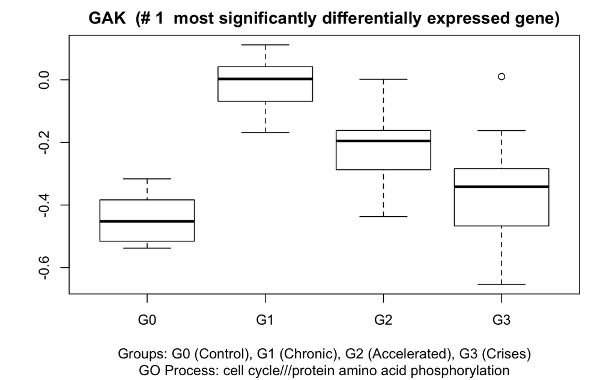

```r
x = 1
#instead of having to look up IDs, just take the xth value of the TopTable...
plot(exprs(gset)[toString(tT[x,1]),] ~ fl #plot expressions for xth most differentially expressed gene
     ,main = paste(tT[x,"Gene.symbol"] , " (#", x, " most significantly differentially expressed gene)")
     ,xlab="Groups: G0 (Control), G1 (Chronic), G2 (Accelerated), G3 (Crises)",ylab=""
     ,sub = paste("GO Process:",tT[x,"GO.Process"]))
```

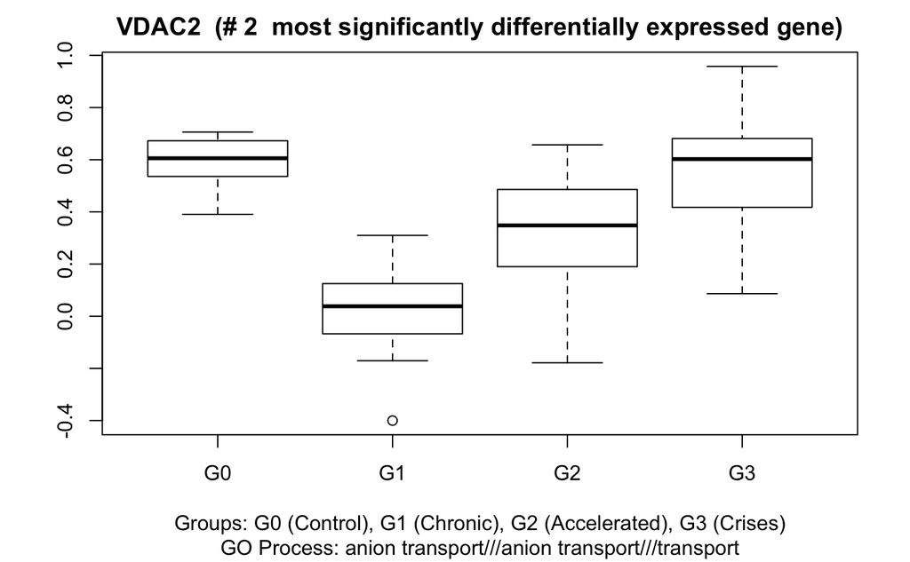

```r
x = 2
#instead of having to look up IDs, just take the xth value of the TopTable...
plot(exprs(gset)[toString(tT[x,1]),] ~ fl #plot expressions for xth most differentially expressed gene
     ,main = paste(tT[x,"Gene.symbol"] , " (#", x, " most significantly differentially expressed gene)")
     ,xlab="Groups: G0 (Control), G1 (Chronic), G2 (Accelerated), G3 (Crises)",ylab=""
     ,sub = paste("GO Process:",tT[x,"GO.Process"]))
```

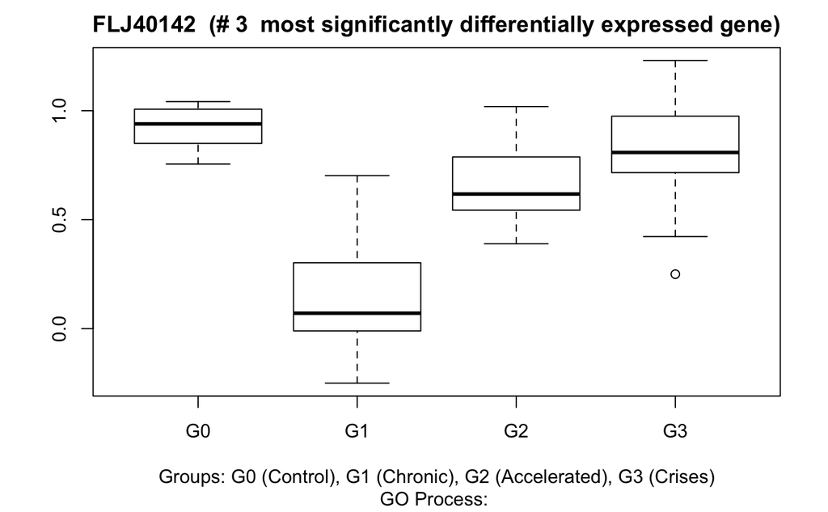

```r
x = 3
#instead of having to look up IDs, just take the xth value of the TopTable...
plot(exprs(gset)[toString(tT[x,1]),] ~ fl #plot expressions for xth most differentially expressed gene
     ,main = paste(tT[x,"Gene.symbol"] , " (#", x, " most significantly differentially expressed gene)")
     ,xlab="Groups: G0 (Control), G1 (Chronic), G2 (Accelerated), G3 (Crises)",ylab=""
     ,sub = paste("GO Process:",tT[x,"GO.Process"]))
```

```r
x = 20
#instead of having to look up IDs, just take the xth value of the TopTable...
plot(exprs(gset)[toString(tT[x,1]),] ~ fl #plot expressions for xth most differentially expressed gene
     ,main = paste(tT[x,"Gene.symbol"] , " (#", x, " most significantly differentially expressed gene)")
     ,xlab="Groups: G0 (Control), G1 (Chronic), G2 (Accelerated), G3 (Crises)",ylab=""
     ,sub = paste("GO Process:",tT[x,"GO.Process"]))
```

[output not shown]

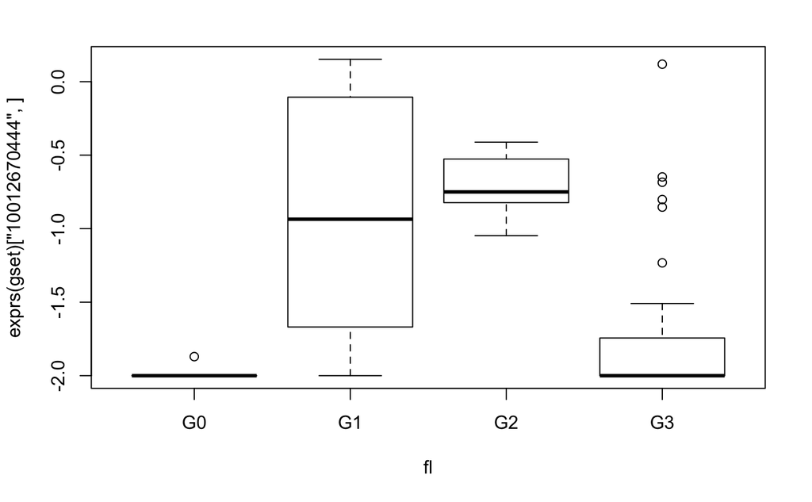

```r
#CAMP, id 10012670444
plot(exprs(gset)["10012670444",] ~ fl) #plot expressions for xth most differentially expressed gene
```

### Sidenote: What if we build a different contrast model? What if we do non pairwise contrasts?

##### When making only 3 pairwise contrasts:G1-G0, G2-G0, G3-G0

```r
#build a linear model...
fit_test <- lmFit(gset, design)
cont.matrix <- makeContrasts(G1-G0, G2-G0, G3-G0, levels=design)
fit2_test <- contrasts.fit(fit_test, cont.matrix)
fit2_test <- eBayes(fit2_test, 0.01)
tT_test <- topTable(fit2_test, adjust="fdr", sort.by="B", number=250) #sort by the lods or B-statistic
```

```r
subset(tT_test, select=c("P.Value","Gene.symbol"
                         ,"G1...G0","G2...G0","G3...G0","AveExpr"))
```

[output not shown]

```r
fit_test <- lmFit(gset, design)
cont.matrix <- makeContrasts((G1+G2+G3)/3-G0, G1-G0, levels=design)
fit2_test <- contrasts.fit(fit_test, cont.matrix)
fit2_test <- eBayes(fit2_test, 0.01)
tT_test <- topTable(fit2_test, adjust="fdr", sort.by="B", number=250) #sort by the lods or B-statistic
```

```r
subset(tT_test, select=c("P.Value","Gene.symbol"
                         ,"X.G1...G2...G3..3...G0","G1...G0","AveExpr"))
```

[output not shown]

Why not follow Radich’ lead: compare chronic with accelerated+blast crisis? But also subtract out healthy CD34 profile from the disease samples.

```r
#write.table(head(tT[1:10,], file=stdout(), row.names=FALSE, sep="\t"))
```

```r
#exprs(gset)
#gset@phenoData@data
#gset$description
##dim(gset@assayData[["exprs"]]) #24481 x 117

g0.means <- rowMeans(exprs(gset)[,which(sml=="G0")])
g1.means <- rowMeans(exprs(gset)[,which(sml=="G1")])
g3.means <- rowMeans(exprs(gset)[,which(sml=="G3")])
```

```r
#create gene list
gene.list.3.1 <- 10^g3.means / 10^g1.means #raw values are all log10 transormed. undo that.
#gene.list.3.1 <- sort(gene.list.3.1, decreasing=TRUE)
gene.list.3.1 <- log(gene.list.3.1, base=2)


gene.list.1.0 <- 10^g1.means / 10^g0.means #raw values are all log10 transormed. undo that.
gene.list.1.0 <- log(gene.list.1.0, base=2)
```

```r
#before passing into the enrichment functions, need to translate proprietary (platform) ids into Entrez gene ids
platform.ids <- names(gene.list.1.0)
#platform.ids
#platform.ids[1:30]

test.gene.list <- gene.list.1.0[gset@featureData@data[,"Gene.ID"] != ""]
test.gene.list[1:10]
```

```
10012665102 10012665103 10012665105 10012665106 10012665108 10012665110 10012665114 10012665116 10012665117
 -1.3124705  -0.5248442  -1.6525718  -1.6737447  -0.2690325   0.4636537  -1.0782425          NA  -0.4167504
10012665118
  0.6224128
```

```r
test.gene.names <- gset@featureData@data[,c("ID","Gene.ID")][gset@featureData@data[,"Gene.ID"] != "",2]
test.gene.names[1:10]
```

```
 [1] "64388"  "140883" "2244"   "286133" "5879"   "55105"  "2823"   "399967" "124565" "150365"
```

```r
## feature 1: numeric vector
test = test.gene.list
## feature 2: named vector
names(test) = test.gene.names
## feature 3: decreasing order
test = sort(test, decreasing = TRUE)

#gset@featureData@data[,"Gene.ID"] != ""
#which(apply(gset@featureData@data[,"Gene.ID"],1,length) > 0)[1:30]
test[1:30]
```

```
    3684     2219      934    79887     6283     2215     9536   144423      383     7305     1536    10288
5.471274 5.317501 5.235324 5.211114 5.170814 5.079044 5.070349 5.038089 4.941359 4.926469 4.878348 4.805924
    8291     2357    26030     3934     8875     3240     8807    26034      240    51296     8218   199675
4.762858 4.740333 4.737145 4.729680 4.721287 4.715599 4.713624 4.684761 4.665555 4.650329 4.645480 4.641555
    1087      306    11240      929     3579     2220
4.629955 4.613814 4.538439 4.512597 4.451375 4.439235
```

so there were a lot of NA rows in the genelist i created. 3k of 18k had to be removed because they were na! Was messing with the enrichment functions.

```r
test <- test[!is.na(test)]
#test[15250:15500] #what is 100128545 doing here??? ...gues it's a legit gene ID
#uhh.... I should get rid of all of these NA values!!!
#good source: https://github.com/GuangchuangYu/DOSE/wiki/how-to-prepare-your-own-geneList
```

### Ok, now lets try some enrichment…

```r
library(clusterProfiler)
library(org.Hs.eg.db)
library(DOSE)
```

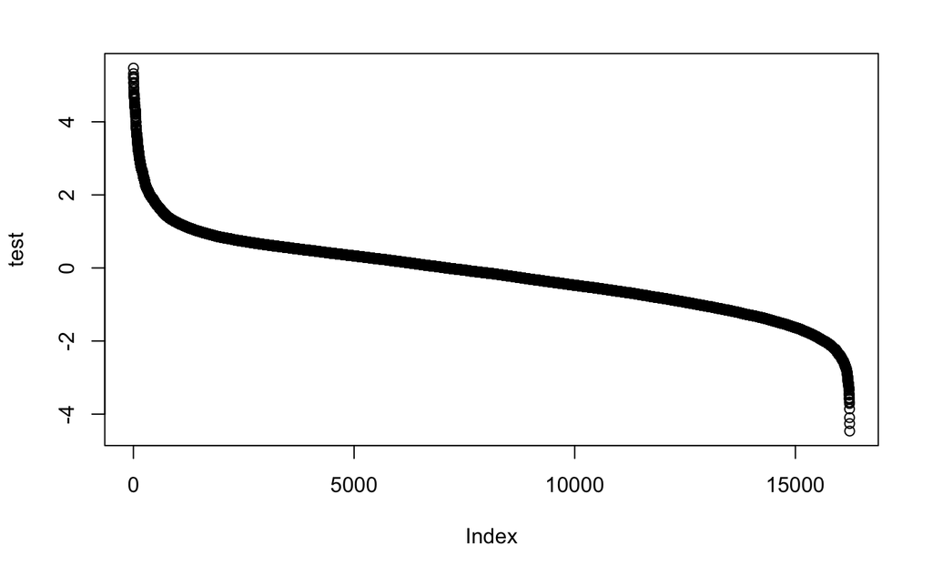

```r
plot(test)
```

```r
gene <- names(test)[abs(test) > 2]
ggo <- groupGO(gene     = gene,
               OrgDb    = org.Hs.eg.db,
               ont      = "MF",
               level    = 2,
               readable = TRUE)
#order by count
ggo@result = ggo@result[order(ggo@result[,"Count"],decreasing=TRUE),]
ggo@result
```

|  | ID | Description | Count | GeneRatio | geneID |
| --- | --- | --- | --- | --- | --- |
| GO:0005488 | GO:0005488 | binding | 743 | 743/912 | ITGAM/FCN1/S100A12/FCGR3B/PTGES/ARG1/TYROBP/CYBB/LILRB2/DYSF…… |
| GO:0003824 | GO:0003824 | catalytic activity | 288 | 288/912 | FCN1/PLBD1/PTGES/GLT1D1/ARG1/CYBB/VNN2/HP/IPCEF1/ALOX5/PADI2…… |
| GO:0098772 | GO:0098772 | molecular function regulator | 123 | 123/912 | PLEKHG3/ANXA3/LGALS3/ALOX5AP/LRRK2/IL1RN/CSTA/CTSH/NCF1/RETN…… |
| GO:0060089 | GO:0060089 | molecular transducer activity | 104 | 104/912 | FCN1/LILRB2/FPR1/IL18RAP/CD14/CXCR2/CLEC4A/FPR2/CTSH/LILRA3/…… |
| GO:0140110 | GO:0140110 | transcription regulator activity | 92 | 92/912 | OLIG1/ELANE/HLX/BCL6/CEBPE/LITAF/CREB5/MAFB/RXRA/CD3D/TCF7/I…… |
| GO:0005215 | GO:0005215 | transporter activity | 64 | 64/912 | CYBB/SLC15A3/KCNJ15/AQP9/AQP9/KCNQ1/SLC7A7/SLC51A/LRP1/S100A…… |
| GO:0005198 | GO:0005198 | structural molecule activity | 37 | 37/912 | CLTCL1/CHI3L1/LRRK2/CSTA/LRRK2/PRG3/COL9A3/VCAN/KRT23/TGFBI/…… |
| GO:0104005 | GO:0104005 | hijacked molecular function | 9 | 9/912 | CLEC5A/CLEC5A/ANPEP/CR1/CD86/CR1/XPR1/ITGA2/HSPA1A |
| GO:0038024 | GO:0038024 | cargo receptor activity | 8 | 8/912 | FPR2/LRP1/APOBR/ACKR3/DMBT1/LRP8/LRP6/LRP6 |
| GO:0016209 | GO:0016209 | antioxidant activity | 6 | 6/912 | HP/IPCEF1/ALOX5AP/EPX/NQO1/PXDN |

[output cut: 5 more lines]

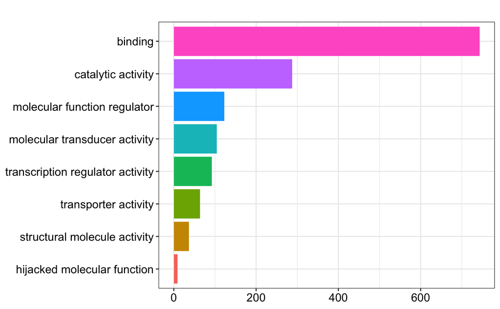

```r
barplot(ggo,showCategory=8)
```

```r
gene <- names(test)[abs(test) > 2]
ggo <- groupGO(gene     = gene,
               OrgDb    = org.Hs.eg.db,
               ont      = "MF",
               level    = 3,
               readable = TRUE)
#order by count
ggo@result = ggo@result[order(ggo@result[,"Count"],decreasing=TRUE),]
ggo@result
```

|  | ID | Description | Count | GeneRatio | geneID |
| --- | --- | --- | --- | --- | --- |
| GO:0005515 | GO:0005515 | protein binding | 623 | 623/912 | ITGAM/FCN1/S100A12/ARG1/TYROBP/CYBB/LILRB2/DYSF/FPR1/PLEKHG3…… |
| GO:0043167 | GO:0043167 | ion binding | 314 | 314/912 | ITGAM/FCN1/S100A12/PTGES/ARG1/CYBB/DYSF/LCN2/ALOX5/ANXA3/PAD…… |
| GO:0097159 | GO:0097159 | organic cyclic compound binding | 249 | 249/912 | CYBB/LGALS3/GIMAP4/CHST15/RAB31/TCN1/LRRK2/MNDA/CKAP4/NUAK2/…… |
| GO:1901363 | GO:1901363 | heterocyclic compound binding | 244 | 244/912 | CYBB/LGALS3/GIMAP4/CHST15/RAB31/TCN1/LRRK2/MNDA/CKAP4/NUAK2/…… |
| GO:0016787 | GO:0016787 | hydrolase activity | 131 | 131/912 | FCN1/PLBD1/ARG1/VNN2/HP/PADI2/FCN2/HPR/MGAM/AZU1/RAB31/DUSP1…… |
| GO:0036094 | GO:0036094 | small molecule binding | 130 | 130/912 | FCN1/CYBB/LCN2/ALOX5AP/GIMAP4/CHST15/CLEC4A/RAB31/TCN1/LRRK2…… |
| GO:0097367 | GO:0097367 | carbohydrate derivative binding | 121 | 121/912 | FCN1/CD14/FCN2/CHI3L1/GIMAP4/CHST15/AZU1/RAB31/LRRK2/CTSG/NU…… |
| GO:0016740 | GO:0016740 | transferase activity | 119 | 119/912 | PTGES/GLT1D1/ALOX5AP/CHST15/LRRK2/IGF2R/NUAK2/LRRK2/BST1/QPC…… |
| GO:0140096 | GO:0140096 | catalytic activity, acting on a protein | 102 | 102/912 | FCN1/HP/FCN2/HPR/AZU1/DUSP13/LRRK2/CTSH/IGF2R/MMP8/FGL2/CTSG…… |
| GO:0038023 | GO:0038023 | signaling receptor activity | 97 | 97/912 | FCN1/LILRB2/FPR1/IL18RAP/CD14/CXCR2/CLEC4A/FPR2/CTSH/LILRA3/…… |

[output cut: 136 more lines]

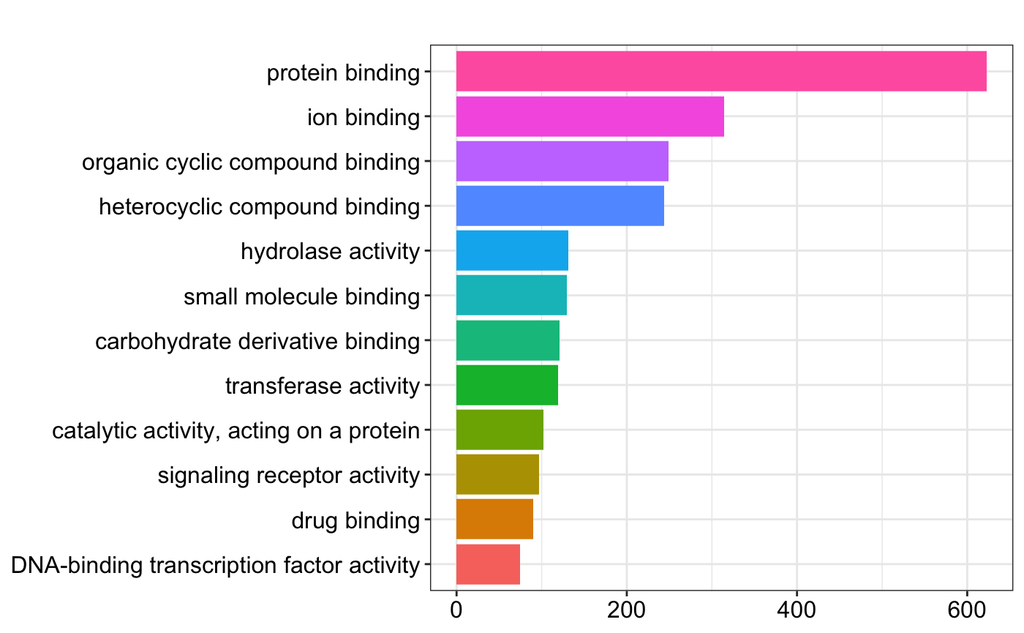

```r
barplot(ggo,showCategory=12)
```

```r
gene <- names(test)[abs(test) > 2]
ggo <- groupGO(gene     = gene,
               OrgDb    = org.Hs.eg.db,
               ont      = "BP",
               level    = 3,
               readable = TRUE)

ggo@result = ggo@result[order(ggo@result[,"Count"],decreasing=TRUE),]

ggo@result
```

|  | ID | Description | Count | GeneRatio | geneID |
| --- | --- | --- | --- | --- | --- |
| GO:0050789 | GO:0050789 | regulation of biological process | 625 | 625/912 | ITGAM/FCN1/S100A12/PTGES/ARG1/TYROBP/CYBB/LILRB2/DYSF/FPR1/P…… |
| GO:0050794 | GO:0050794 | regulation of cellular process | 589 | 589/912 | ITGAM/FCN1/S100A12/PTGES/ARG1/TYROBP/CYBB/LILRB2/DYSF/FPR1/P…… |
| GO:0071704 | GO:0071704 | organic substance metabolic process | 534 | 534/912 | ITGAM/FCN1/PLBD1/S100A12/PTGES/ARG1/CYBB/LILRB2/DYSF/FPR1/LC…… |
| GO:0044237 | GO:0044237 | cellular metabolic process | 521 | 521/912 | ITGAM/PLBD1/S100A12/PTGES/ARG1/CYBB/LILRB2/DYSF/FPR1/VNN2/HP…… |
| GO:0044238 | GO:0044238 | primary metabolic process | 512 | 512/912 | ITGAM/FCN1/PLBD1/S100A12/PTGES/ARG1/CYBB/LILRB2/DYSF/FPR1/HP…… |
| GO:0006807 | GO:0006807 | nitrogen compound metabolic process | 492 | 492/912 | ITGAM/FCN1/PLBD1/S100A12/PTGES/ARG1/CYBB/LILRB2/DYSF/FPR1/VN…… |
| GO:0051716 | GO:0051716 | cellular response to stimulus | 449 | 449/912 | ITGAM/FCN1/S100A12/PTGES/ARG1/TYROBP/CYBB/LILRB2/DYSF/FPR1/P…… |
| GO:0007154 | GO:0007154 | cell communication | 407 | 407/912 | ITGAM/FCN1/S100A12/PTGES/ARG1/TYROBP/CYBB/LILRB2/FPR1/PLEKHG…… |
| GO:0007165 | GO:0007165 | signal transduction | 385 | 385/912 | ITGAM/FCN1/S100A12/PTGES/ARG1/TYROBP/CYBB/LILRB2/FPR1/PLEKHG…… |
| GO:0048518 | GO:0048518 | positive regulation of biological process | 373 | 373/912 | ITGAM/FCN1/S100A12/ARG1/CYBB/LILRB2/DYSF/FPR1/LCN2/HP/IL18RA…… |

[output cut: 548 more lines]

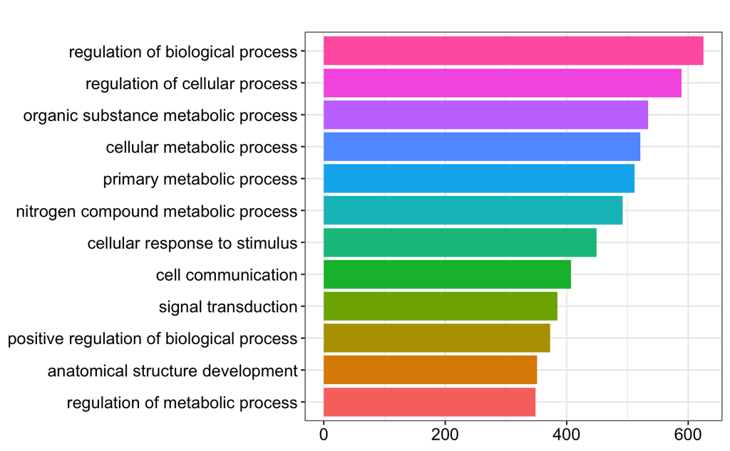

```r
barplot(ggo,showCategory=12)
```

Further information about enirchment scores: https://yulab-smu.github.io/clusterProfiler-book/chapter2.html#gene-set-enrichment-analysis

```r
#KEGG Gene Set Enrichment Analysis
kk2 <- gseKEGG(geneList     = test,
               organism     = 'hsa',
               nPerm        = 1000,
               minGSSize    = 100,
               pvalueCutoff = 0.05,
               verbose      = FALSE)
```

```
There are ties in the preranked stats (0.4% of the list).
The order of those tied genes will be arbitrary, which may produce unexpected results.There are duplicate gene names, fgsea may produce unexpected results
```

```r
kk2@result = kk2@result[order(kk2@result[,"setSize"],decreasing=TRUE),]
kk2@result
```

|  | ID | Description | setSize | enrichmentScore | NES | pvalue | p.adjust | qvalues | rank | leading_edge | core_enrichment |
| --- | --- | --- | --- | --- | --- | --- | --- | --- | --- | --- | --- |
| hsa05200 | hsa05200 | Pathways in cancer | 458 | 0.2403397 | 1.353325 | 0.017543860 | 0.03693444 | 0.016037323 | 2592 | tags=23%, list=16%, signal=20% | 7039/23604/196883/3560/1441/3570/3566/6256/6932/83593/27436/…… |
| hsa04151 | hsa04151 | PI3K-Akt signaling pathway | 303 | 0.2376294 | 1.288387 | 0.010204082 | 0.02332362 | 0.010127359 | 3815 | tags=22%, list=24%, signal=17% | 3685/6198/4893/26281/2260/59345/57521/2335/10681/3569/23678/…… |
| hsa05165 | hsa05165 | Human papillomavirus infection | 267 | 0.3156233 | 1.695589 | 0.009174312 | 0.02224076 | 0.009657170 | 2354 | tags=23%, list=15%, signal=20% | 1299/3134/10312/10312/5829/9586/6932/3107/3106/5595/7482/832…… |
| hsa04080 | hsa04080 | Neuroactive ligand-receptor interaction | 258 | 0.3083987 | 1.667330 | 0.008928571 | 0.02224076 | 0.009657170 | 4210 | tags=42%, list=26%, signal=32% | 2357/2358/1511/53637/135/5729/706/51738/719/1241/728/4987/30…… |
| hsa04010 | hsa04010 | MAPK signaling pathway | 254 | 0.2399627 | 1.278579 | 0.010101010 | 0.02332362 | 0.010127359 | 3089 | tags=27%, list=19%, signal=22% | 929/7039/776/3554/5595/5058/2316/5880/409/4215/356/55799/808…… |
| hsa04060 | hsa04060 | Cytokine-cytokine receptor interaction | 232 | 0.4055668 | 2.145040 | 0.009009009 | 0.02224076 | 0.009657170 | 3032 | tags=34%, list=19%, signal=28% | 8807/3579/3557/4050/4050/3577/1230/8794/7133/8794/6352/3624/…… |
| hsa04144 | hsa04144 | Endocytosis | 201 | 0.4053610 | 2.078571 | 0.008264463 | 0.02224076 | 0.009657170 | 1472 | tags=19%, list=9%, signal=17% | 8218/3579/11031/3482/3577/3134/9922/64411/3560/84440/9267/31…… |
| hsa05166 | hsa05166 | Human T-cell leukemia virus 1 infection | 194 | 0.2666884 | 1.377259 | 0.014285714 | 0.03088803 | 0.013411908 | 2354 | tags=19%, list=15%, signal=17% | 3689/3134/196883/706/3560/9586/3554/7850/915/3107/3106/5595/…… |
| hsa05163 | hsa05163 | Human cytomegalovirus infection | 191 | 0.3905283 | 2.005523 | 0.007299270 | 0.02085506 | 0.009055485 | 2503 | tags=26%, list=15%, signal=23% | 3579/1230/6352/3134/5829/196883/3587/9586/3554/3570/3570/310…… |
| hsa04015 | hsa04015 | Rap1 signaling pathway | 180 | 0.3437283 | 1.751663 | 0.006944444 | 0.02057613 | 0.008934373 | 2354 | tags=25%, list=15%, signal=22% | 3684/2357/3689/135/196883/64411/7408/83593/26037/2533/5595/3…… |

[output cut: 30 more lines]

```r
#KEGG over representation Analysis
kk3 <- enrichKEGG(gene    = names(test),
               organism     = 'hsa',
               pvalueCutoff = 0.05
  )
kk3@result[,c("Description","GeneRatio","p.adjust","Count")]
```

|  | Description | GeneRatio | p.adjust | Count |
| --- | --- | --- | --- | --- |
| hsa04110 | Cell cycle | 117/5603 | 1.519569e-08 | 117 |
| hsa04151 | PI3K-Akt signaling pathway | 303/5603 | 1.519569e-08 | 303 |
| hsa05166 | Human T-cell leukemia virus 1 infection | 194/5603 | 5.227902e-08 | 194 |
| hsa04010 | MAPK signaling pathway | 254/5603 | 7.468306e-08 | 254 |
| hsa04015 | Rap1 signaling pathway | 180/5603 | 1.615953e-06 | 180 |
| hsa05202 | Transcriptional misregulation in cancer | 163/5603 | 3.944984e-06 | 163 |
| hsa04520 | Adherens junction | 69/5603 | 5.123327e-06 | 69 |
| hsa04640 | Hematopoietic cell lineage | 90/5603 | 5.797798e-06 | 90 |
| hsa05152 | Tuberculosis | 156/5603 | 1.104496e-05 | 156 |
| hsa05212 | Pancreatic cancer | 71/5603 | 1.104496e-05 | 71 |

[output cut: 305 more lines]

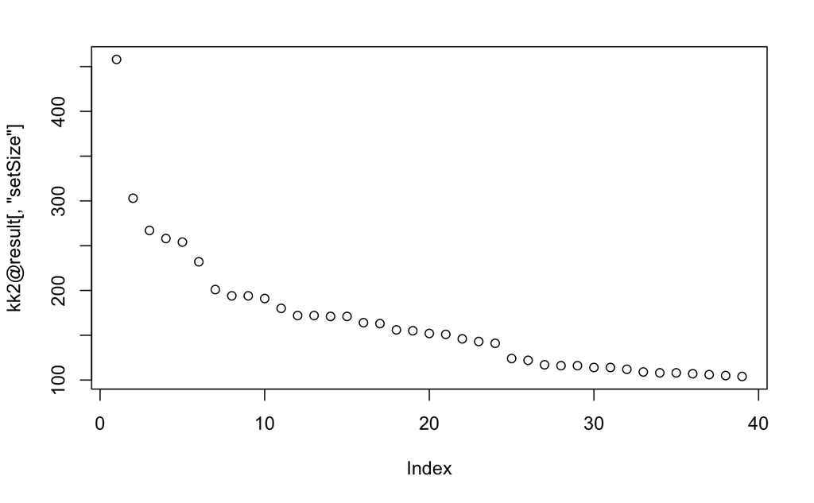

```r
plot(kk2@result[,"setSize"])
```

```r
library(GSEABase)
library(tidyr)
```

```r
gene <- names(test)[abs(test) > 2]

wpgmtfile <- system.file("extdata", "wikipathways-20180810-gmt-Homo_sapiens.gmt", package="clusterProfiler")
wp2gene <- read.gmt(wpgmtfile) #i had to install GSEAbase first ??
wp2gene <- wp2gene %>% tidyr::separate(ont, c("name","version","wpid","org"), "%")
wpid2gene <- wp2gene %>% dplyr::select(wpid, gene) #TERM2GENE
wpid2name <- wp2gene %>% dplyr::select(wpid, name) #TERM2NAME

ewp <- enricher(gene, TERM2GENE = wpid2gene, TERM2NAME = wpid2name)
ewp <- setReadable(ewp, org.Hs.eg.db, keyType = "ENTREZID")
ewp@result = ewp@result[order(ewp@result[,"Count"],decreasing=TRUE),]
ewp@result
```

|  | ID | Description | GeneRatio | BgRatio | pvalue | p.adjust | qvalue | geneID | Count |
| --- | --- | --- | --- | --- | --- | --- | --- | --- | --- |
| WP2882 | WP2882 | Nuclear Receptors Meta-Pathway | 28/388 | 321/6249 | 4.095917e-02 | 0.7691030111 | 0.7602806419 | ALOX5AP/TGFA/G6PD/CES1/RGS2/MYOF/RXRA/CPEB4/SLC39A8/ACKR3/GPAM/EHHADH/NQO1/DNAJB1/NRIP1/MYC/ABCC4/TSC22D3/NR0B2/ACADM/HSPA1A/MAFF/HSP90AA1/IL1B/SLC39A10/SLCO1B1/EGR1/ABCB1 | 28 |
| WP4172 | WP4172 | PI3K-Akt Signaling Pathway | 23/388 | 345/6249 | 3.914563e-01 | 0.9916742832 | 0.9802988022 | COL9A3/TGFA/IL2RB/CREB5/CSF3R/IL6R/IL4R/PIK3CG/TLR2/IFNB1/RELN/FGF4/PDGFC/BDNF/CDK6/MYC/ITGA2/HSP90AA1/KIT/IL7/ANGPT1/LAMA1/FLT3 | 23 |
| WP3888 | WP3888 | VEGFA-VEGFR2 Signaling Pathway | 21/388 | 238/6249 | 6.380244e-02 | 0.7691030111 | 0.7602806419 | NCF1/TNFRSF10C/PXN/PLAUR/PRKCD/MYH9/PTPN6/PTPRJ/ACKR3/INPP4B/FHL2/HSPA1A/HSP90AA1/GJA1/GAB1/DKK1/NR4A1/EGR1/PRKD1/EEA1/WASF1 | 21 |
| WP3932 | WP3932 | Focal Adhesion-PI3K-Akt-mTOR-signaling pathway | 21/388 | 309/6249 | 3.645954e-01 | 0.9806357782 | 0.9693869197 | ITGB2/IL2RB/PFKFB4/CREB5/CSF3R/IL6R/IL4R/ITGAX/PFKFB2/PIK3CG/IFNB1/RELN/FGF4/PDGFC/ITGA2/HSP90AA1/KIT/ANGPT1/COL11A1/FGF16/LAMA1 | 21 |
| WP2431 | WP2431 | Spinal Cord Injury | 20/388 | 120/6249 | 4.103470e-05 | 0.0042676087 | 0.0042186550 | ARG1/LILRB2/LGALS3/LTB/VCAN/FCGR2A/IL1R1/LTB4R/PLA2G2A/BDNF/MYC/CCNG1/RGMA/GJA1/IL1B/MBP/NR4A1/EGR1/E2F5/CXCL2 | 20 |
| WP2806 | WP2806 | Human Complement System | 17/388 | 98/6249 | 9.260321e-05 | 0.0072230501 | 0.0071401946 | FCN1/FPR1/FCN2/ITGB2/FCGR3A/ELANE/CFP/CFD/CR1/PLAUR/C3AR1/C5AR1/ITGAX/WAS/TLR2/CFH/ITGA2 | 17 |
| WP2877 | WP2877 | Vitamin D Receptor Pathway | 17/388 | 186/6249 | 6.906871e-02 | 0.7691030111 | 0.7602806419 | ITGAM/ALOX5/CD14/TREM1/S100A6/BCL6/ORM2/G6PD/RXRA/STEAP4/CRACR2B/NRIP1/MYC/DUSP10/TNFSF4/ABCB1/TIMP3 | 17 |
| WP382 | WP382 | MAPK Signaling Pathway | 17/388 | 249/6249 | 3.776371e-01 | 0.9830760816 | 0.9717992305 | CD14/LRRK2/CACNA1D/PRKCD/IL1R1/IL1R2/MAP3K20/FGF4/BDNF/MAPK10/MYC/HSPA1A/NF1/IL1B/DUSP10/NR4A1/FGF16 | 17 |
| WP455 | WP455 | GPCRs, Class A Rhodopsin-like | 17/388 | 258/6249 | 4.358641e-01 | 0.9981937432 | 0.9867434775 | FPR1/CXCR2/FPR2/CXCR1/CCR1/ADORA2A/PTGDR/C3AR1/LTB4R/GPR68/OPRL1/GPR65/ACKR3/F2RL1/CHRM3/HTR1F/ADRA2A | 17 |
| WP3945 | WP3945 | TYROBP Causal Network | 16/388 | 63/6249 | 8.843877e-07 | 0.0002759290 | 0.0002727638 | ITGAM/TYROBP/IGSF6/ITGB2/SLC7A7/TNFRSF1B/HLX/TCIRG1/IL10RA/PPP1R18/HCLS1/ITGAX/BIN2/ABCC4/CYTL1/RGS1 | 16 |

[output cut: 302 more lines]

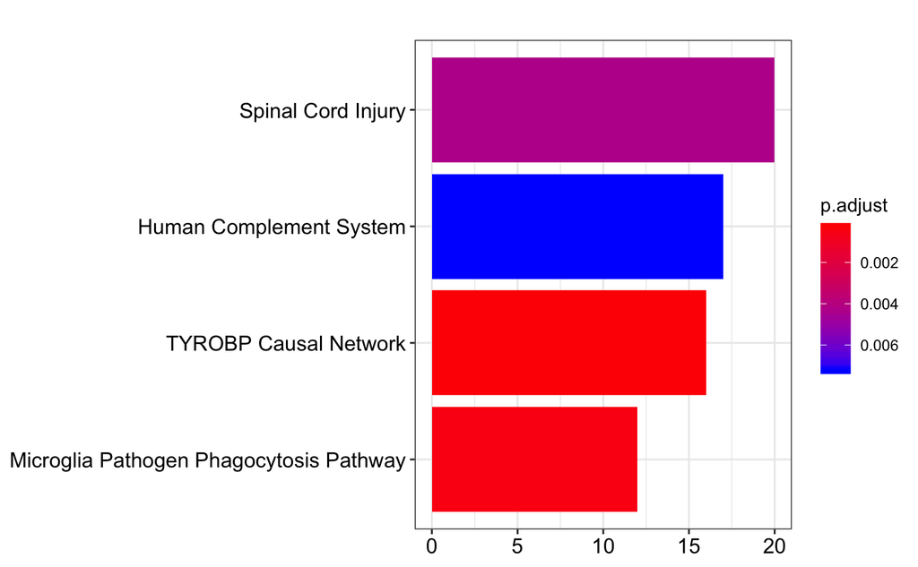

```r
barplot(ewp,showCategory=12)
```

```r
ewp2 <- GSEA(test, TERM2GENE = wpid2gene, TERM2NAME = wpid2name, verbose=FALSE)
```

```
There are ties in the preranked stats (0.4% of the list).
The order of those tied genes will be arbitrary, which may produce unexpected results.There are duplicate gene names, fgsea may produce unexpected resultsno term enriched under specific pvalueCutoff...
```

```r
ewp2 <- setReadable(ewp2, org.Hs.eg.db, keyType = "ENTREZID")
ewp2@result = ewp2@result[order(ewp2@result[,"setSize"],decreasing=TRUE),]
ewp2@result
```

| ID | Description | setSize | enrichmentScore | NES | pvalue | p.adjust | qvalues |
| --- | --- | --- | --- | --- | --- | --- | --- |

```r
gset@featureData@data[which(gset@featureData@data[,"Gene.ID"]==100128545),c("ID","Gene.ID")]
```

```r
################################################################
#   Boxplot for selected GEO samples
#library(Biobase)
#library(GEOquery)

# load series and platform data from GEO

suppressMessages(gset <- getGEO("GSE4170", GSEMatrix =TRUE, getGPL=FALSE))
if (length(gset) > 1) idx <- grep("GPL2029", attr(gset, "names")) else idx <- 1
gset <- gset[[idx]]

# group names for all samples in a series
gsms <- paste0("000000111111111111222222222222222X22222X2222122122",
        "22555555555555555555555552222255555555555555555555",
        "5555555555555522222")
sml <- c()
for (i in 1:nchar(gsms)) { sml[i] <- substr(gsms,i,i) }
sml <- paste("G", sml, sep="") #set group names

# eliminate samples marked as "X"
sel <- which(sml != "X")
sml <- sml[sel]
gset <- gset[ ,sel]

# order samples by group
ex <- exprs(gset)[ , order(sml)]
sml <- sml[order(sml)]
fl <- as.factor(sml)
labels <- c("cd","ap","bc","resistant","responder","chronic")

# set parameters and draw the plot
palette(c("#dfeaf4","#f4dfdf","#f2cb98","#dfeaf4","#f4dfdf","#dfeaf4", "#AABBCC"))
dev.new(width=4+dim(gset)[[2]]/5, height=6)
par(mar=c(2+round(max(nchar(sampleNames(gset)))/2),4,2,1))
title <- paste ("GSE4170", '/', annotation(gset), " selected samples", sep ='')
boxplot(ex[,1:20], boxwex=0.6, notch=T, main=title, outline=FALSE, las=2, col=fl) #ben: only take first 20 columns
legend("topleft", labels, fill=palette(), bty="n")
```

```r
# set parameters and draw the plot
palette(c("#dfeaf4","#f4dfdf","#f2cb98", "#AABBCC"))
dev.new(width=4+dim(gset)[[2]]/5, height=6)
par(mar=c(2+round(max(nchar(sampleNames(gset)))/2),4,2,1))
title <- paste ("GSE4170", '/', annotation(gset), " selected samples", sep ='')
boxplot(ex[,0:20], boxwex=0.6, notch=T, main=title, outline=FALSE, las=2, col=fl) #ben: only take first 20 columns
legend("topleft", labels, fill=palette(), bty="n")
```

### Step 2: Repeat the analysis for the other study

```r
# Version info: R 3.2.3, Biobase 2.30.0, GEOquery 2.40.0, limma 3.26.8
# R scripts generated  Thu Mar 28 05:38:05 EDT 2019

################################################################
#   Differential expression analysis with limma
library(Biobase)
library(GEOquery)
library(limma)

# load series and platform data from GEO

gset <- getGEO("GSE14671", GSEMatrix =TRUE, AnnotGPL=TRUE)
if (length(gset) > 1) idx <- grep("GPL570", attr(gset, "names")) else idx <- 1
gset <- gset[[idx]]

# make proper column names to match toptable
fvarLabels(gset) <- make.names(fvarLabels(gset))

# group names for all samples
gsms <- "33333333333344444444444444444444444433333344444444444444444"
sml <- c()
for (i in 1:nchar(gsms)) { sml[i] <- substr(gsms,i,i) }

# log2 transform
ex <- exprs(gset)
qx <- as.numeric(quantile(ex, c(0., 0.25, 0.5, 0.75, 0.99, 1.0), na.rm=T))
LogC <- (qx[5] > 100) ||
          (qx[6]-qx[1] > 50 && qx[2] > 0) ||
          (qx[2] > 0 && qx[2] < 1 && qx[4] > 1 && qx[4] < 2)
if (LogC) { ex[which(ex <= 0)] <- NaN
  exprs(gset) <- log2(ex) }

# set up the data and proceed with analysis
sml <- paste("G", sml, sep="")    # set group names
fl <- as.factor(sml)
gset$description <- fl
design <- model.matrix(~ description + 0, gset)
colnames(design) <- levels(fl)
fit <- lmFit(gset, design)
cont.matrix <- makeContrasts(G4-G3, levels=design)
fit2 <- contrasts.fit(fit, cont.matrix)
fit2 <- eBayes(fit2, 0.01)
tT <- topTable(fit2, adjust="fdr", sort.by="B", number=250)
```

```r
tT <- subset(tT, select=c("ID","adj.P.Val","P.Value","Gene.symbol","Gene.title","Gene.ID","GO.Function","GO.Process"))
write.table(head(tT, file=stdout(), row.names=F, sep="\t"))
```

the “profile graph” didn’t quite work as nicely (the Radich study, just had to enter one of the internal gene IDs). Here, it required opening a spearate file to look for the ID to profile.

“This tab allows you to view a specific gene expression profile graph by entering the corresponding identifier from the ID column of the Platform record. This feature does not perform any calculations; it merely displays the expression values of the gene across Samples. Sample groups may or may not be defined for this feature to work.”

```r
################################################################
#   Boxplot for selected GEO samples
library(Biobase)
library(GEOquery)

# load series and platform data from GEO

gset <- getGEO("GSE14671", GSEMatrix =TRUE, getGPL=FALSE)
if (length(gset) > 1) idx <- grep("GPL570", attr(gset, "names")) else idx <- 1
gset <- gset[[idx]]

# group names for all samples in a series
gsms <- "33333333333344444444444444444444444433333344444444444444444"
sml <- c()
for (i in 1:nchar(gsms)) { sml[i] <- substr(gsms,i,i) }
sml <- paste("G", sml, sep="")  #set group names

# order samples by group
ex <- exprs(gset)[ , order(sml)]
sml <- sml[order(sml)]
fl <- as.factor(sml)
labels <- c("cd","ap","bc","resistant","responder")
```

```r
# set parameters and draw the plot
palette(c("#dfeaf4","#f4dfdf","#f2cb98","#dfeaf4","#f4dfdf", "#AABBCC"))
dev.new(width=4+dim(gset)[[2]]/5, height=6)
par(mar=c(2+round(max(nchar(sampleNames(gset)))/2),4,2,1))
title <- paste ("GSE14671", '/', annotation(gset), " selected samples", sep ='')
boxplot(ex, boxwex=0.6, notch=T, main=title, outline=FALSE, las=2, col=fl)
legend("topleft", labels, fill=palette(), bty="n")
```

So, both datasets are loaded. They total less than 80MB each. Would be more interesting to eventually get gene-level info (splits by funcitonal pathway,etc).

But first step is to aggregate the 2 datasets together. Questions to ask: are the ranges and distributions the same for both datasets, roughly? Do the 2 populations look similar in terms of value range or even distribution (bimodal, normal, etc)? *If not very similar… is there similarity WITHIN the populations of one study? or is the population within a study as ~heterogeneious as when compared ‘across’ studies?

+do i need to normalize the ranges or what? to get similaris distributions…?

NExt, are the “top 250” genes identified by the GEO2R default comparison… how similar is the “top 250” lists for the 2 studies? *This will lead naturally into a categorization of the genes in the 3 main pathways of interest. May also want to see highly expressed genes vs. normal patient levels (which should… highlight more genes that are members of the 3 pathways, id think)